# Exploring Website Click Data

Celia Taylor

June 27, 2016

###### This is from https://rpubs.com/tmcfl/simulated-click-analysis

###### This tutorial is based on the EDA Exercises in the book, Doing Data Science, which I highly recommend.

###### There are 31 data sets named nyt1.csv, nyt2.csv,…, nyt31.csv, which can be downloaded from GitHub.

###### Each csv represents one (simulated) days worth of ads shown and clicks recorded on the New York

###### Times homepage in May 2012. Each row in the csv represents a single user.

###### There are five columns: Age, Gender (0=female, 1=male), Impressions, Clicks, and

###### Signed_In status (0=not signed in, 1=signed in).

###### Create a data frame called data1 from the nyt1.csv file

```r
#Create a data frame called data1 from the nyt1.csv file
fileLocation <- "http://stat.columbia.edu/~rachel/datasets/nyt1.csv"
data1 <- read.csv(url(fileLocation))
head(data1)
```

```
##   Age Gender Impressions Clicks Signed_In
## 1  36      0           3      0         1
## 2  73      1           3      0         1
## 3  30      0           3      0         1
## 4  49      1           3      0         1
## 5  47      1          11      0         1
## 6  47      0          11      1         1
```

```r
# Use the section below if you would rather import the data from a local file
# fileLocation <- "~/path/for/the/file/nyt1.csv"
# data1 <- read.csv("fileLocation")
```

```r
#Take a look at the first 5 rows to get a feel for the data
head(data1)
```

```
##   Age Gender Impressions Clicks Signed_In
## 1  36      0           3      0         1
## 2  73      1           3      0         1
## 3  30      0           3      0         1
## 4  49      1           3      0         1
## 5  47      1          11      0         1
## 6  47      0          11      1         1
```

###### You can get a overview of the structure of the data by using the str() function

```r
#You can get a overview of the structure of the data by using the str() function
# str stands for 'structure'
# str() returns information about each column such as name, data type, etc.
str(data1)
```

```
## 'data.frame':    458441 obs. of  5 variables:
##  $ Age        : int  36 73 30 49 47 47 0 46 16 52 ...
##  $ Gender     : int  0 1 0 1 1 0 0 0 0 0 ...
##  $ Impressions: int  3 3 3 3 11 11 7 5 3 4 ...
##  $ Clicks     : int  0 0 0 0 0 1 1 0 0 0 ...
##  $ Signed_In  : int  1 1 1 1 1 1 0 1 1 1 ...
```

###### It could also be helpful to look at a summary of the data. This gives you useful

###### information such as the number of rows in the object, and the mean, median, and

###### range (min-max) of each column

```r
#It could also be helpful to look at a summary of the data. This gives you useful
#information such as the number of rows in the object, and the mean, median, and
#range (min-max) of each column.
summary(data1)
```

```
##       Age             Gender       Impressions         Clicks
##  Min.   :  0.00   Min.   :0.000   Min.   : 0.000   Min.   :0.00000
##  1st Qu.:  0.00   1st Qu.:0.000   1st Qu.: 3.000   1st Qu.:0.00000
##  Median : 31.00   Median :0.000   Median : 5.000   Median :0.00000
##  Mean   : 29.48   Mean   :0.367   Mean   : 5.007   Mean   :0.09259
##  3rd Qu.: 48.00   3rd Qu.:1.000   3rd Qu.: 6.000   3rd Qu.:0.00000
##  Max.   :108.00   Max.   :1.000   Max.   :20.000   Max.   :4.00000
##    Signed_In
##  Min.   :0.0000
##  1st Qu.:0.0000
##  Median :1.0000
##  Mean   :0.7009
##  3rd Qu.:1.0000
##  Max.   :1.0000
```

###### Since we’re exploring, it’s helpful to visualize the distribution of some of

###### the columns, so we can see what we’re working with and if anything looks out

###### of the ordinary.

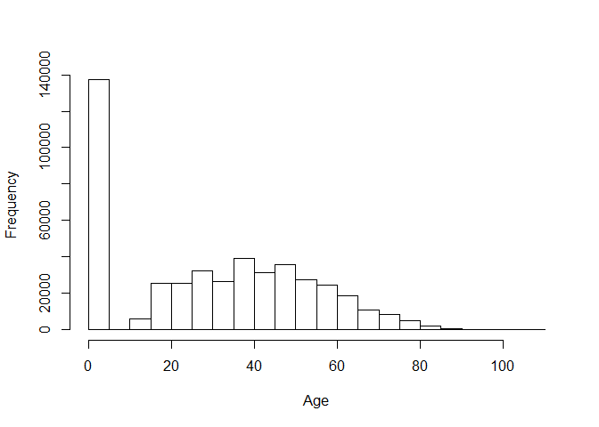

```r
#Since we’re exploring, it’s helpful to visualize the distribution of some of
#the columns, so we can see what we’re working with and if anything looks out
#of the ordinary.
# distribution of the Age column
hist(data1$Age, main="", xlab="Age")
```

```r
range(data1$Age)
```

```
## [1]   0 108
```

###### Distribution of the Impressions column

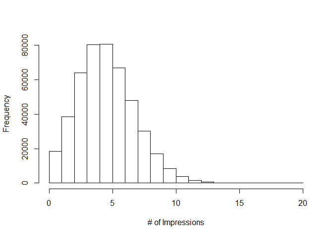

```r
# Distribution of the Impressions column
hist(data1$Impressions, main="", xlab="# of Impressions")
```

```r
range(data1$Impressions)
```

```
## [1]  0 20
```

###### Distribution of the Clicks column

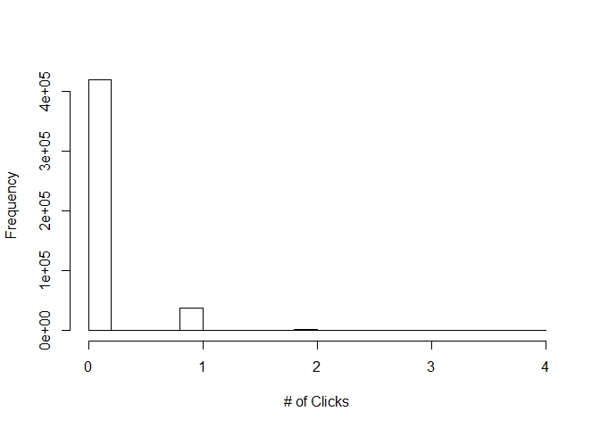

```r
# Distribution of the Clicks column
hist(data1$Clicks, main="", xlab="# of Clicks")
```

```r
range(data1$Clicks)
```

```
## [1] 0 4
```

###### Did you notice that there is a disproportionate number of ages recorded as zero?

###### This could skew our analysis, so we may need to account for that later.

##### Task 1

###### create a new variable named Age_Group, that groups users into age categories

###### “<18”, “18-24”, “25-34”, “35-44”, “45-54”, “55-64”, and “65+”

###### 1.1) Cut the ages into the desired groups and add the groups to a new column

###### in data1 called Age_Group. The ‘cut’ function creates a factor with levels.

```r
######1.1) Cut the ages into the desired groups and add the groups to a new column
######in data1 called Age_Group. The ‘cut’ function creates a factor with levels.
data1$Age_Group <- cut(data1$Age, c(-Inf, 18, 24, 34, 44, 54, 64, Inf))
# Name the levels of 'Age_Group' for readability
levels(data1$Age_Group) <- c("<18", "18-24", "25-34", "35-44", "45-54", "55-64", "65+")
```

###### Take a look at the changes:

```r
#Take a look at the changes:
head(data1)
```

```
##   Age Gender Impressions Clicks Signed_In Age_Group
## 1  36      0           3      0         1     35-44
## 2  73      1           3      0         1       65+
## 3  30      0           3      0         1     25-34
## 4  49      1           3      0         1     45-54
## 5  47      1          11      0         1     45-54
## 6  47      0          11      1         1     45-54
```

##### Task 2

###### For a single day, plot the distributions of ‘number of impressions’ and

###### ‘click-through-rate’ by Age_Group. (CTR = clicks/impressions).

###### 2.1) Create a subset of data1 to exclude rows where there are no impressions

###### (if there are no impressions, we assume there will be no clicks). Name the new

###### object d1

```r
#2.1) Create a subset of data1 to exclude rows where there are no impressions
#(if there are no impressions, we assume there will be no clicks). Name the new
#object d1
d1 <- subset(data1, Impressions>0)
```

###### 2.2) Add a column to d1 called CTR containing the click-through-rate

```r
#2.2) Add a column to d1 called CTR containing the click-through-rate
d1$CTR <- d1$Clicks/d1$Impressions
head(d1)
```

```
##   Age Gender Impressions Clicks Signed_In Age_Group        CTR
## 1  36      0           3      0         1     35-44 0.00000000
## 2  73      1           3      0         1       65+ 0.00000000
## 3  30      0           3      0         1     25-34 0.00000000
## 4  49      1           3      0         1     45-54 0.00000000
## 5  47      1          11      0         1     45-54 0.00000000
## 6  47      0          11      1         1     45-54 0.09090909
```

###### 2.3) Plot the distribution of Impressions>0, grouped by Age_Group,

###### using the ggplot2 package.

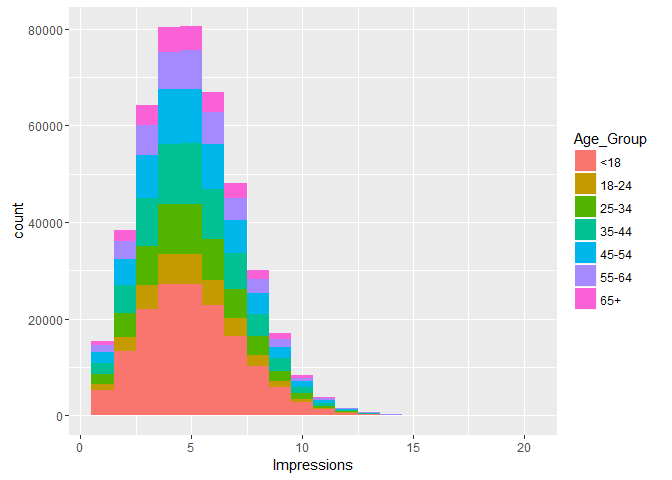

```r
#2.3) Plot the distribution of Impressions>0, grouped by Age_Group,
#using the ggplot2 package.
library(ggplot2) # used for visualizations
ggplot(subset(d1, Impressions>0), aes(x=Impressions, fill=Age_Group))+
    geom_histogram(binwidth=1)
```

###### 2.4) Plot the distribution of CTR>0, grouped by Age_Group

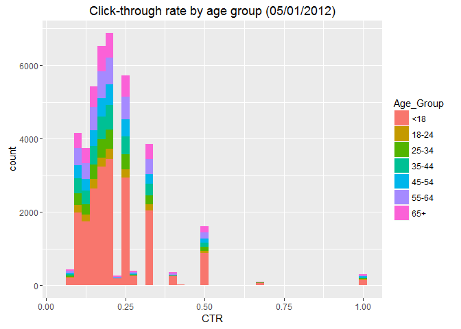

```r
#2.4) Plot the distribution of CTR>0, grouped by Age_Group
ggplot(subset(d1, CTR>0), aes(x=CTR, fill=Age_Group))+
    labs(title="Click-through rate by age group (05/01/2012)")+
    geom_histogram(binwidth=.025)
```

###### Create a data frame called data14 from the nyt14.csv file

```r
#Create a data frame called data14 from the nyt14.csv file
fileLocation <- "http://stat.columbia.edu/~rachel/datasets/nyt14.csv"
data14 <- read.csv(url(fileLocation))
head(data14)
```

```
##   Age Gender Impressions Clicks Signed_In
## 1  17      1           7      0         1
## 2  54      1           7      0         1
## 3  53      1           3      0         1
## 4  65      1           4      0         1
## 5  25      1           1      0         1
## 6  54      0           7      0         1
```

```r
# Use the section below if you would rather import the data from a local file
# fileLocation <- "~/path/for/the/file/nyt14.csv"
# data14 <- read.csv("fileLocation")
```

```r
#Take a look at the first 5 rows to get a feel for the data
head(data14)
```

```
##   Age Gender Impressions Clicks Signed_In
## 1  17      1           7      0         1
## 2  54      1           7      0         1
## 3  53      1           3      0         1
## 4  65      1           4      0         1
## 5  25      1           1      0         1
## 6  54      0           7      0         1
```

###### You can get a overview of the structure of the data by using the str() function

```r
#You can get a overview of the structure of the data by using the str() function
# str stands for 'structure'
# str() returns information about each column such as name, data type, etc.
str(data14)
```

```
## 'data.frame':    440338 obs. of  5 variables:
##  $ Age        : int  17 54 53 65 25 54 46 63 53 44 ...
##  $ Gender     : int  1 1 1 1 1 0 0 1 0 0 ...
##  $ Impressions: int  7 7 3 4 1 7 7 10 6 5 ...
##  $ Clicks     : int  0 0 0 0 0 0 0 0 0 0 ...
##  $ Signed_In  : int  1 1 1 1 1 1 1 1 1 1 ...
```

###### It could also be helpful to look at a summary of the data. This gives you useful

###### information such as the number of rows in the object, and the mean, median, and

###### range (min-max) of each column

```r
#It could also be helpful to look at a summary of the data. This gives you useful
#information such as the number of rows in the object, and the mean, median, and
#range (min-max) of each column.
summary(data14)
```

```
##       Age             Gender        Impressions         Clicks
##  Min.   :  0.00   Min.   :0.0000   Min.   : 0.000   Min.   :0.00000
##  1st Qu.:  0.00   1st Qu.:0.0000   1st Qu.: 3.000   1st Qu.:0.00000
##  Median : 31.00   Median :0.0000   Median : 5.000   Median :0.00000
##  Mean   : 29.46   Mean   :0.3699   Mean   : 4.998   Mean   :0.09137
##  3rd Qu.: 48.00   3rd Qu.:1.0000   3rd Qu.: 6.000   3rd Qu.:0.00000
##  Max.   :105.00   Max.   :1.0000   Max.   :20.000   Max.   :4.00000
##    Signed_In
##  Min.   :0.0000
##  1st Qu.:0.0000
##  Median :1.0000
##  Mean   :0.6996
##  3rd Qu.:1.0000
##  Max.   :1.0000
```

###### Since we’re exploring, it’s helpful to visualize the distribution of some of

###### the columns, so we can see what we’re working with and if anything looks out

###### of the ordinary.

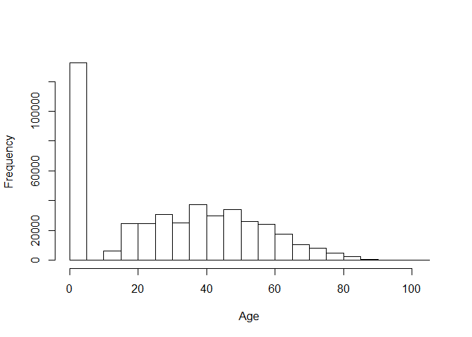

```r
#Since we’re exploring, it’s helpful to visualize the distribution of some of
#the columns, so we can see what we’re working with and if anything looks out
#of the ordinary.
# distribution of the Age column
hist(data14$Age, main="", xlab="Age")
```

```r
range(data14$Age)
```

```
## [1]   0 105
```

###### Distribution of the Impressions column

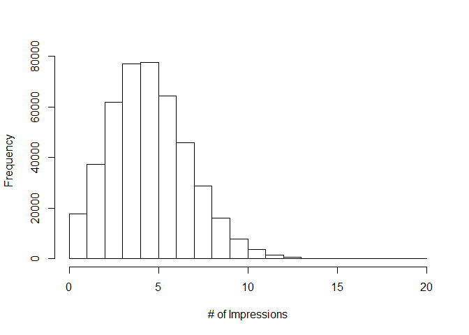

```r
# Distribution of the Impressions column
hist(data14$Impressions, main="", xlab="# of Impressions")
```

```r
range(data14$Impressions)
```

```
## [1]  0 20
```

###### Distribution of the Clicks column

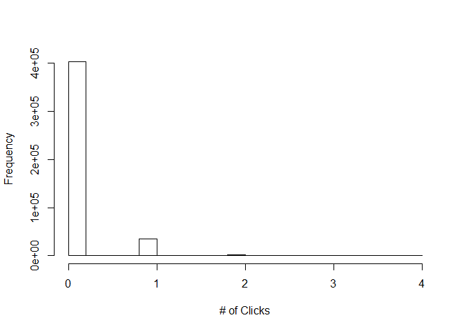

```r
# Distribution of the Clicks column
hist(data14$Clicks, main="", xlab="# of Clicks")
```

```r
range(data14$Clicks)
```

```
## [1] 0 4
```

###### Did you notice that there is a disproportionate number of ages recorded as zero?

###### This could skew our analysis, so we may need to account for that later.

##### Task 1

###### create a new variable named Age_Group, that groups users into age categories

###### “<18”, “18-24”, “25-34”, “35-44”, “45-54”, “55-64”, and “65+”

###### 1.1) Cut the ages into the desired groups and add the groups to a new column

###### in data14 called Age_Group. The ‘cut’ function creates a factor with levels.

```r
######1.1) Cut the ages into the desired groups and add the groups to a new column
######in data14 called Age_Group. The ‘cut’ function creates a factor with levels.
data14$Age_Group <- cut(data14$Age, c(-Inf, 18, 24, 34, 44, 54, 64, Inf))
# Name the levels of 'Age_Group' for readability
levels(data14$Age_Group) <- c("<18", "18-24", "25-34", "35-44", "45-54", "55-64", "65+")
```

###### Take a look at the changes:

```r
#Take a look at the changes:
head(data14)
```

```
##   Age Gender Impressions Clicks Signed_In Age_Group
## 1  17      1           7      0         1       <18
## 2  54      1           7      0         1     45-54
## 3  53      1           3      0         1     45-54
## 4  65      1           4      0         1       65+
## 5  25      1           1      0         1     25-34
## 6  54      0           7      0         1     45-54
```

##### Task 2

###### For a single day, plot the distributions of ‘number of impressions’ and

###### ‘click-through-rate’ by Age_Group. (CTR = clicks/impressions).

###### 2.1) Create a subset of data14 to exclude rows where there are no impressions

```r
#2.1) Create a subset of data14 to exclude rows where there are no impressions
#(if there are no impressions, we assume there will be no clicks). Name the new
#object d14
d14 <- subset(data14, Impressions>0)
```

```r
#2.2) Add a column to d14 called CTR containing the click-through-rate
d14$CTR <- d14$Clicks/d14$Impressions
head(d14)
```

```
##   Age Gender Impressions Clicks Signed_In Age_Group CTR
## 1  17      1           7      0         1       <18   0
## 2  54      1           7      0         1     45-54   0
## 3  53      1           3      0         1     45-54   0
## 4  65      1           4      0         1       65+   0
## 5  25      1           1      0         1     25-34   0
## 6  54      0           7      0         1     45-54   0
```

###### 2.3) Plot the distribution of Impressions>0, grouped by Age_Group,

###### using the ggplot2 package.

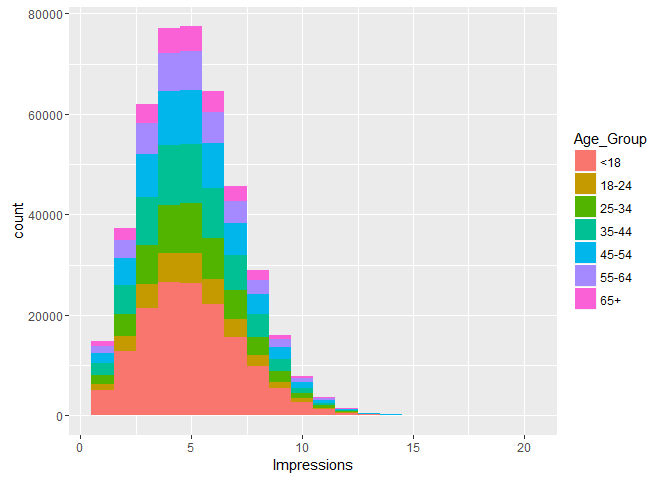

```r
#2.3) Plot the distribution of Impressions>0, grouped by Age_Group,
#using the ggplot2 package.
library(ggplot2) # used for visualizations
ggplot(subset(d14, Impressions>0), aes(x=Impressions, fill=Age_Group))+
    geom_histogram(binwidth=1)
```

###### 2.4) Plot the distribution of CTR>0, grouped by Age_Group

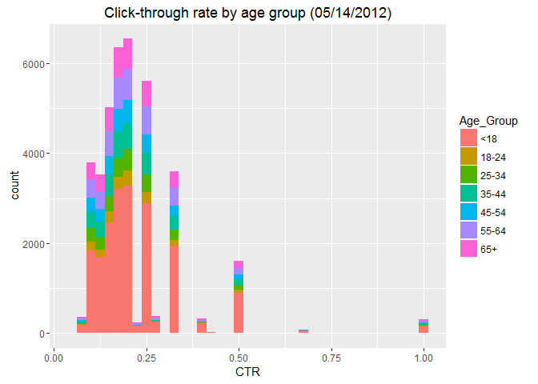

```r
#2.4) Plot the distribution of CTR>0, grouped by Age_Group
ggplot(subset(d14, CTR>0), aes(x=CTR, fill=Age_Group))+
    labs(title="Click-through rate by age group (05/14/2012)")+
    geom_histogram(binwidth=.025)
```